# Reproducible Research: Peer Assessment 1

Download libraries used in the following analyses:

```r
library(dplyr)
library(ggplot2)
```

## Loading and preprocessing the data

The following analysis entails performing diagnostic statistics and graphs based on an individual’s monitoring device data. The data provides step activity for 5 minute intervals in a period from October to November 2012.

Start by downloading the data (Note: first set working directory to location with file):

```r
ActTable <- read.csv("activity.csv",stringsAsFactors = FALSE)
str(ActTable)
```

```
## 'data.frame':    17568 obs. of  3 variables:
##  $ steps   : int  NA NA NA NA NA NA NA NA NA NA ...
##  $ date    : chr  "2012-10-01" "2012-10-01" "2012-10-01" "2012-10-01" ...
##  $ interval: int  0 5 10 15 20 25 30 35 40 45 ...
```

## What is mean total number of steps taken per day?

The first exercise will help understand average steps per day by calculating the mean and median and looking at some simple graphs.

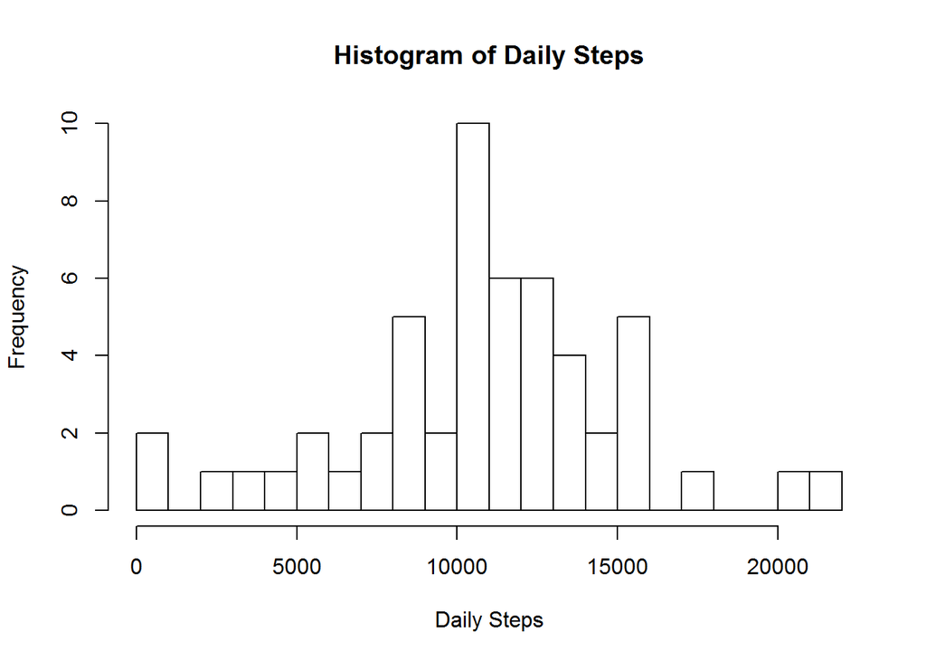

```r
AT_Group_Date <- ActTable %>%
            group_by(date) %>%
            summarise(TotalSteps = sum(steps))
AT_Group_Date$date <- as.Date(AT_Group_Date$date)

hist(AT_Group_Date$TotalSteps, breaks = 20, xlab = "Daily Steps",
     main = "Histogram of Daily Steps")
```

```r
mean(AT_Group_Date$TotalSteps, na.rm = TRUE)
```

```
## [1] 10766.19
```

```r
median(AT_Group_Date$TotalSteps, na.rm = TRUE)
```

```
## [1] 10765
```

## What is the average daily activity pattern?

Next we will observe how the different 5 minute intervals compare to each other across the data set.

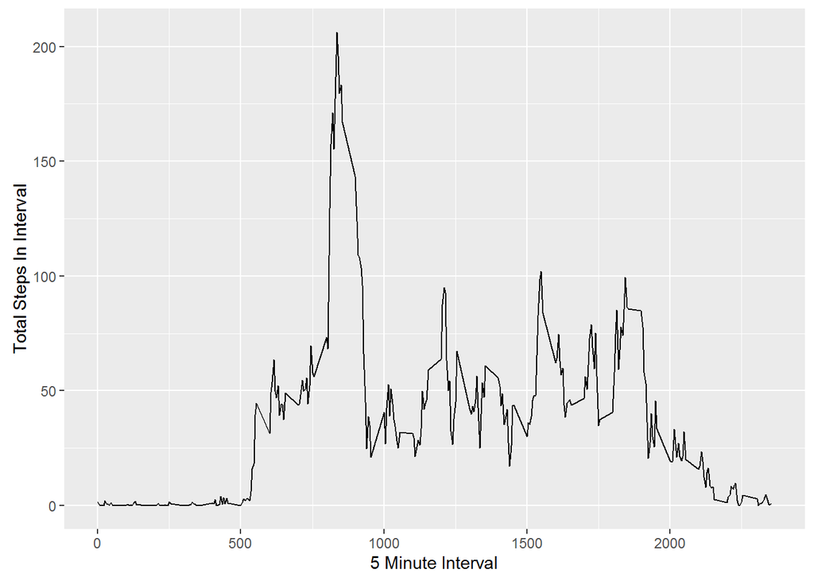

```r
AT_Group_Interval <- ActTable %>%
                  group_by(interval) %>%
                  summarise(Average_Int_Steps = mean(steps, na.rm = TRUE))
ggplot(AT_Group_Interval,  aes(x = interval, y = Average_Int_Steps)) + geom_line() + ylab("Total Steps In Interval") + xlab("5 Minute Interval")
```

```r
AT_Group_Interval[AT_Group_Interval$Average_Int_Steps ==
                  max(AT_Group_Interval$Average_Int_Steps,na.rm = TRUE),]
```

```
## Source: local data frame [1 x 2]
##
##   interval Average_Int_Steps
##      (int)             (dbl)
## 1      835          206.1698
```

The interval with the highest mean steps across the data is interval 835, averaging 206.17 steps.

## Imputing missing values

There are a number of days/intervals where there are missing values which are coded as NA in the data. Instead of treating these as zeros for our statistics, we will use the interval means calculated above as placeholders to see if the missing data is significantly impacting the statistics.

```r
sum(is.na(ActTable$steps))
```

```
## [1] 2304
```

```r
ActTable2 <- left_join(x = ActTable, y = AT_Group_Interval, by = "interval")
head(ActTable2)
```

```
##   steps       date interval Average_Int_Steps
## 1    NA 2012-10-01        0         1.7169811
## 2    NA 2012-10-01        5         0.3396226
## 3    NA 2012-10-01       10         0.1320755
## 4    NA 2012-10-01       15         0.1509434
## 5    NA 2012-10-01       20         0.0754717
## 6    NA 2012-10-01       25         2.0943396
```

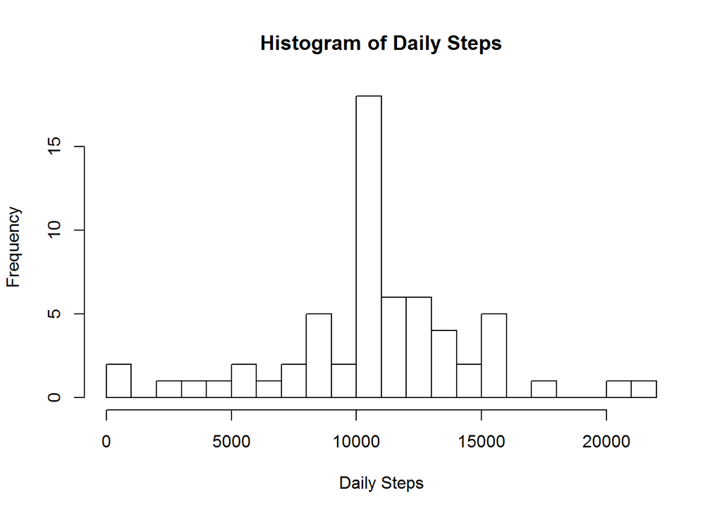

```r
ActTable2$steps_clean <- ActTable2$Average_Int_Steps
for(i in 1:nrow(ActTable2)){
  if(is.na(ActTable2$steps[i]) == FALSE){
  ActTable2$steps_clean[i] <- ActTable2$steps[i]
  }
}

AT_Group_Date2 <- ActTable2 %>%
  group_by(date) %>%
  summarise(TotalSteps = sum(steps_clean))
AT_Group_Date2$date <- as.Date(AT_Group_Date2$date)

hist(AT_Group_Date2$TotalSteps, breaks = 20, xlab = "Daily Steps",
     main = "Histogram of Daily Steps")
```

```r
mean(AT_Group_Date2$TotalSteps, na.rm = TRUE)
```

```
## [1] 10766.19
```

```r
median(AT_Group_Date2$TotalSteps, na.rm = TRUE)
```

```
## [1] 10766.19
```

## Are there differences in activity patterns between weekdays and weekends?

Finally, we consider interval activity on weekdays versus weekend to see if this variable has a significant impact on daily activity as we may expect.

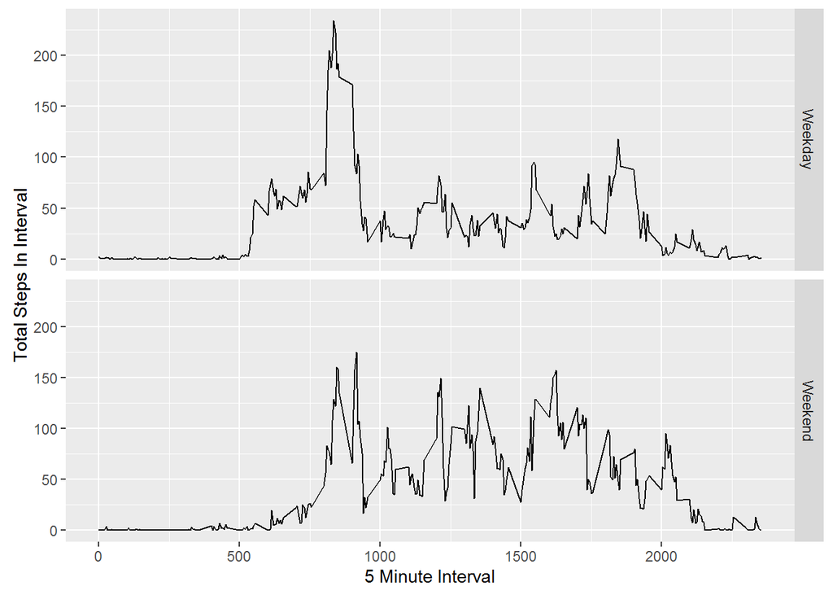

```r
ActTable2$WeekendFlag <- factor(rep("Weekday",nrow(ActTable2)),levels =
                                  c("Weekday", "Weekend"))
ActTable2$WeekendFlag[weekdays(as.Date(ActTable2$date)) %in% c("Saturday", "Sunday")] <- "Weekend"

AT_Group_Interval2 <- ActTable2 %>%
  group_by(interval,WeekendFlag) %>%
  summarise(Average_Int_Steps = mean(steps, na.rm = TRUE))

ggplot(AT_Group_Interval2,  aes(x = interval, y = Average_Int_Steps)) +
  geom_line() + facet_grid(WeekendFlag ~.)+ ylab("Total Steps In Interval") + xlab("5 Minute Interval")
```

It appears that during the weekend, activities tend to start later, there is a lower morning peak and activity throughout the middle of the day is consistently higher.